# Mini-Course on Panel Data Causal Inference with a Continuous Treatment

Session 0: Introduction

Brantly Callaway

brantly.callaway@uga.edu

University of Georgia

September 18, 2026

## Overview of the Course

$\newcommand{\E}{\mathbb{E}} \newcommand{\E}{\mathbb{E}} \newcommand{\var}{\mathrm{var}} \newcommand{\cov}{\mathrm{cov}} \newcommand{\Var}{\mathrm{var}} \newcommand{\Cov}{\mathrm{cov}} \newcommand{\Corr}{\mathrm{corr}} \newcommand{\corr}{\mathrm{corr}} \newcommand{\L}{\mathrm{L}} \renewcommand{\P}{\mathrm{P}} \newcommand{\ACR}{\mathrm{ACR}} \newcommand{\ATT}{\mathrm{ATT}} \newcommand{\ACRT}{\mathrm{ACRT}} \newcommand{\T}{\mathrm{T}} \newcommand{\independent}{{\perp\!\!\!\perp}} \newcommand{\indicator}[1]{ \mathbf{1}\{#1\} }$

0. Introduction to difference-in-differences
1. Difference-in-differences with a continuous treatment
2. Assessing strong parallel trends via close comparison groups
3. Shift-share designs

## Materials for the Course

Available on my website: https://bcallaway11.github.io/ull

- All slides
- Links to main reference papers for each topic

# Introduction to Difference-in-Differences with a Binary Treatment

1. Panel Data Causal Inference: Challenges and Opportunities
2. DiD with Two Periods
3. Staggered Treatment Adoption
   - Issues with Traditional Regression Approaches
   - New Approaches
4. Empirical Application

## Main References for This Session

- A. Baker et al. (2026), *Journal of Economic Literature*
- Callaway (2023), *Handbook of Labor, Human Resources, and Population Economics*

## Additional Resources

Advanced Materials: https://github.com/bcallaway11/bank-of-portugal

- Relaxing the parallel trends assumption by including covariates
- Common issues in empirical work
- Dealing with more complicated treatment regimes
- Alternative identification strategies (e.g., conditioning on lagged outcome, change-in-changes, others)

## Running Example

Running Example: Causal effect of a state-level minimum wage increase on employment

- Widely studied using DiD identification strategies (Card and Krueger (1994), many others)
- For today: very simplified version with
  1. No changes in federal minimum wage
  2. “Binarized” state minimum wages (i.e., state minimum wage is either above the federal minimum wage or not)

# Part 1 Panel Data Causal Inference: Challenges and Opportunities

## Research Design

Pre-Post Design:

1. Two periods of panel data
2. No units treated in first period
3. Some units become treated in second period while other units remain untreated

Staggered Adoption Design:

1. Multiple periods of panel data
2. Units can become treated at different points in time, then remains treated

These types of research design are a key distinguishing feature of modern approaches to panel data causal inference relative to traditional panel data models

- It also explains why the methods we consider today are often grouped among quasi-experimental methods such as IV or RD.

## Treatment Effect Heterogeneity

Modern approaches also typically allow for treatment effect heterogeneity

- That is, that effects of the treatment can vary across different units in potentially complicated ways

This is going to be a major issue in the discussion below

We’ll consider implications for “traditional” regression approaches and how new approaches are designed to handle this

## Forward-Engineering

Forward-Engineering: Identification first, then estimation

- i.e., prioritize clearly defining target parameters and arguments for identifying assumptions
- if possible, use estimators that directly implement identification strategy

Reverse-Engineering: Prioritize estimation (for economists, often some form of regression)

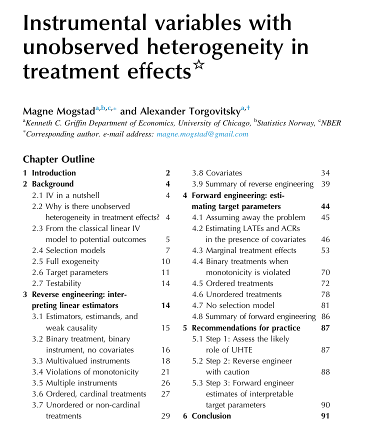

## Notation for Setting with Two Periods

Data:

- 2 periods: $t=1$, $t=2$
  - No one treated until period $t=2$
  - Some units remain untreated in period $t=2$
- $D_{it}$ treatment indicator in period $t$
- 2 groups: $G_i=1$ or $G_i=0$ (treated and untreated)

Potential Outcomes: $Y_{it}(1)$ and $Y_{it}(0)$

Observed Outcomes: $Y_{it=2}$ and $Y_{it=1}$

$$\begin{align*}
Y_{it=2} = G_i Y_{it=2}(1) +(1-G_i)Y_{it=2}(0) \quad \textrm{and} \quad Y_{it=1} = Y_{it=1}(0)
\end{align*}$$

## Target Parameter

Average Treatment Effect on the Treated:
$$\ATT = \E[Y_{t=2}(1) - Y_{t=2}(0) | G=1]$$

Explanation: Mean difference between treated and untreated potential outcomes in the second period among the treated group

## How to Use Panel Data to Learn about $\mathbf{\ATT}$

$$\begin{align*}
\ATT = \color{#4B8B3B}{\underbrace{\E[Y_{t=2}(1) | G=1]}_{\textrm{Easy}}} - \color{#BA0C2F}{\underbrace{\E[Y_{t=2}(0) | G=1]}_{\textrm{Hard}}}
\end{align*}$$

With panel data, we can re-write this as

$$\begin{align*}
\ATT = \color{#4B8B3B}{\E[Y_{t=2}(1) - Y_{t=1}(0) | G=1]} - \color{#BA0C2F}{\E[Y_{t=2}(0) - Y_{t=1}(0) | G=1]}
\end{align*}$$

The first term is how outcomes changed over time for the treated group

- We can directly estimate this from the data

## How to Use Panel Data to Learn about $\mathbf{\ATT}$

$$\begin{align*}
\ATT = \color{#4B8B3B}{\underbrace{\E[Y_{t=2}(1) | G=1]}_{\textrm{Easy}}} - \color{#BA0C2F}{\underbrace{\E[Y_{t=2}(0) | G=1]}_{\textrm{Hard}}}
\end{align*}$$

With panel data, we can re-write this as

$$\begin{align*}
\ATT = \color{#4B8B3B}{\E[Y_{t=2}(1) - Y_{t=1}(0) | G=1]} - \color{#BA0C2F}{\E[Y_{t=2}(0) - Y_{t=1}(0) | G=1]}
\end{align*}$$

The second term is how outcomes would have changed over time if the treated group had not been treated

- Not directly observed in the data $\implies$ we need to make identifying assumptions
- There are many possibilities here:
  1. Before-after: $\color{#BA0C2F}{\E[Y_{t=2}(0) - Y_{t=1}(0) | G=1]} = 0$

## How to Use Panel Data to Learn about $\mathbf{\ATT}$

$$\begin{align*}
\ATT = \color{#4B8B3B}{\underbrace{\E[Y_{t=2}(1) | G=1]}_{\textrm{Easy}}} - \color{#BA0C2F}{\underbrace{\E[Y_{t=2}(0) | G=1]}_{\textrm{Hard}}}
\end{align*}$$

With panel data, we can re-write this as

$$\begin{align*}
\ATT = \color{#4B8B3B}{\E[Y_{t=2}(1) - Y_{t=1}(0) | G=1]} - \color{#BA0C2F}{\E[Y_{t=2}(0) - Y_{t=1}(0) | G=1]}
\end{align*}$$

The second term is how outcomes *would have changed over time* if the treated group had not been treated

- Not directly observed in the data $\implies$ we need to make identifying assumptions
- There are many possibilities here:
  2. Lagged outcome unconfoundedness: $\color{#BA0C2F}{\E[Y_{t=2}(0) - Y_{t=1}(0) | G=1]} = \E\Big[ \E[Y_{t=2}(0) - Y_{t=1}(0) | Y_{t=1}, G=0] \Big| G=1\Big]$

## How to Use Panel Data to Learn about $\mathbf{\ATT}$

$$\begin{align*}
\ATT = \color{#4B8B3B}{\underbrace{\E[Y_{t=2}(1) | G=1]}_{\textrm{Easy}}} - \color{#BA0C2F}{\underbrace{\E[Y_{t=2}(0) | G=1]}_{\textrm{Hard}}}
\end{align*}$$

With panel data, we can re-write this as

$$\begin{align*}
\ATT = \color{#4B8B3B}{\E[Y_{t=2}(1) - Y_{t=1}(0) | G=1]} - \color{#BA0C2F}{\E[Y_{t=2}(0) - Y_{t=1}(0) | G=1]}
\end{align*}$$

The second term is how outcomes *would have changed over time* if the treated group had not been treated

- Not directly observed in the data $\implies$ we need to make identifying assumptions
- There are many possibilities here:
  3. Change-in-changes: $\color{#BA0C2F}{\E[Y_{t=2}(0) - Y_{t=1}(0) | G=1]} = \E\Big[ Q_{Y_{t=2}(0)|G=0}\big(F_{Y_{t=1}(0)|G=0}(Y_{t=1}(0))\big) - Y_{t=1}(0) \Big| G=1\Big]$

## How to Use Panel Data to Learn about $\mathbf{\ATT}$

$$\begin{align*}
\ATT = \color{#4B8B3B}{\underbrace{\E[Y_{t=2}(1) | G=1]}_{\textrm{Easy}}} - \color{#BA0C2F}{\underbrace{\E[Y_{t=2}(0) | G=1]}_{\textrm{Hard}}}
\end{align*}$$

With panel data, we can re-write this as

$$\begin{align*}
\ATT = \color{#4B8B3B}{\E[Y_{t=2}(1) - Y_{t=1}(0) | G=1]} - \color{#BA0C2F}{\E[Y_{t=2}(0) - Y_{t=1}(0) | G=1]}
\end{align*}$$

The second term is how outcomes *would have changed over time* if the treated group had not been treated

- Not directly observed in the data $\implies$ we need to make identifying assumptions
- There are many possibilities here:
  4. Difference-in-differences: ➡

# Part 2 DiD with Two Periods

## DiD with Two Periods

**Parallel Trends Assumption**

$$\color{#BA0C2F}{\E[\Delta Y(0) | G=1]} = \color{#336699}{\E[\Delta Y(0) | G=0]}$$

Explanation: Mean path of untreated potential outcomes is the same for the treated group as for the untreated group

Identification: Under PTA, we can identify $\ATT$:
$$\begin{aligned}
\ATT &= \color{#4B8B3B}{\E[\Delta Y | G=1]} - \color{#BA0C2F}{\E[\Delta Y(0) | G=1]}
\end{aligned}$$

## DiD with Two Periods

**Parallel Trends Assumption**

$$\color{#BA0C2F}{\E[\Delta Y(0) | G=1]} = \color{#336699}{\E[\Delta Y(0) | G=0]}$$

Explanation: Mean path of untreated potential outcomes is the same for the treated group as for the untreated group

Identification: Under PTA, we can identify $\ATT$:
$$\begin{aligned}
\ATT &= \color{#4B8B3B}{\E[\Delta Y | G=1]} - \color{#BA0C2F}{\E[\Delta Y(0) | G=1]}\\
&= \color{#4B8B3B}{\E[\Delta Y | G=1]} - \color{#336699}{\E[\Delta Y | G=0]}
\end{aligned}$$

$\implies \ATT$ is identified can be recovered by the difference in outcomes over time (difference 1) relative to the difference in outcomes over time for the untreated group (difference 2)

[Why is parallel trends a common assumption in economics?]

## Estimation

The most straightforward approach to estimation is the plugin estimator:

$$\widehat{\ATT} = \frac{1}{n_1} \sum_{i=1}^n G_i \Delta Y_i - \frac{1}{n_0} \sum_{i=1}^n (1-G_i) \Delta Y_i$$

## Estimation

An alternative approach is to use a TWFE regression:
$$Y_{it} = \theta_t + \eta_i + \alpha D_{it} + e_{it}$$

- Even though it looks like this model has restricted the effect of participating in the treatment to be constant (and equal to $\alpha$) across all individuals, TWFE (in this case) is actually robust to treatment effect heterogeneity.
- To see this, notice that (with two periods) the previous regression is equivalent to
  $$\begin{align*}
  \Delta Y_{it} = \Delta \theta_t + \alpha \Delta D_{it} + \Delta e_{it}
  \end{align*}$$
  This is fully saturated in $\Delta D_{it}$ (which is binary) $\implies$
  $$\begin{align*}
  \alpha = \E[\Delta Y_{t}|G=1] - \E[\Delta Y_{t}|G=0] = \ATT
  \end{align*}$$

## TWFE Regression

It’s easy to make the TWFE regression more complicated:

- Multiple time periods
- Variation in treatment timing
- More complicated treatments
- Introducing additional covariates

Unfortunately, the robustness of TWFE regressions to treatment effect heterogeneity or these more complicated (and empirically relevant) settings does not seem to hold

- Much of the recent (mostly negative) literature on TWFE in the context of DiD has considered these types of “realistic” settings
- Next, we will consider one of these settings: staggered treatment adoption

# Part 3 Staggered Treatment Adoption

## Setup with Staggered Treatment Adoption

$\T$ time periods

Staggered treatment adoption: Units can become treated at different points in time, but once a unit becomes treated, it remains treated.

Examples:

- Government policies that roll out in different locations at different times (minimum wage is close to this over short time horizons)
- “Scarring” treatments: e.g., job displacement does not typically happen year after year, but rather labor economists think of being displaced as changing a person’s “state” (the treatment is more like: has a person ever been displaced)

## Setup with Staggered Treatment Adoption

Notation:

- In math, staggered treatment adoption means: $D_{it-1}=1 \implies D_{it}=1$.
- $G_i$ — a unit’s group — the time period that unit becomes treated.
  - Under staggered treatment adoption, fully summarizes a unit’s treatment regime
- Define $U_i=1$ for never-treated units and $U_i=0$ otherwise.

## Setup with Staggered Treatment Adoption

Notation (cont’d):

- Potential outcomes: $Y_{it}(g)$ — the outcome that unit $i$ would experience in time period $t$ if they became treated in period $g$.
- Untreated potential outcome: $Y_{it}(0)$ — the outcome unit $i$ would experience in time period $t$ if they did not participate in the treatment in any period.
- Observed outcome: $Y_{it}=Y_{it}(G_i)$
- No anticipation condition: $Y_{it} = Y_{it}(0)$ for all $t < G_i$ (pre-treatment periods for unit $i$)

## Target Parameters

Group-time average treatment effects:
$$\begin{align*}
\ATT(g,t) = \E[Y_t(g) - Y_t(0) | G=g]
\end{align*}$$

Explanation: $\ATT$ for group $g$ in time period $t$

## Target Parameters

Event Study:
$$\begin{align*}
\ATT^{es}(e) = \E[ Y_{g+e}(G) - Y_{g+e}(0) | G \in \mathcal{G}_e]
\end{align*}$$

where $\mathcal{G}_e$ is the set of groups observed to have experienced the treatment for $e$ periods at some point.

Explanation: $\ATT$ when units have been treated for $e$ periods

## Target Parameters

Overall $\mathbf{\ATT}$:

Towards this end: the average treatment effect for unit $i$ (across its post-treatment time periods) is given by:
$$\bar{\tau}_i(G_i) = \frac{1}{\T - G_i + 1} \sum_{t=G_i}^{\T} \Big( Y_{it}(G_i) - Y_{it}(0) \Big)$$

Then,

$$\begin{align*}
\ATT^o = \E[\bar{\tau}(G) | U=0]
\end{align*}$$

Explanation: $\ATT$ across all units that every participate in the treatment

## Pros & Cons of Aggregating Causal Effect Parameters

#### Group-Time $\mathbf{\ATT(g,t)}$

- More fully characterizes treatment effect heterogeneity.
- Some theories may have testable implications on $\ATT(g,t)$ (e.g., on the sign of group-time average treatment effects).

⟶

⟶

#### Event Study $\mathbf{\ATT^{es}(e)}$

- Easier to estimate precisely
- Easier to report - summarizes treatment effects in a two-dimensional plot.

#### Overall $\mathbf{\ATT^o}$

- Easiest to estimate precisely
- Easiest to report - summarizes causal effects into single number to report in abstract or introduction.

## $\mathbf{\ATT(g,t)}$ as a Building Block

To understand the discussion later, it is also helpful to think of $\ATT(g,t)$ as a building block for the other parameters discussed above. For example:

Overall ATT:
$$\begin{align*}
\ATT^o = \sum_{g \in \bar{\mathcal{G}}} \sum_{t=g}^{\T} w^o(g,t) \ATT(g,t) \qquad \qquad \textrm{where} \quad w^o(g,t) = \frac{\P(G=g|U=0)}{\T-g+1}
\end{align*}$$

Event Study: Likewise, $\ATT^{es}(e)$ is a weighted average of $\ATT(g,g+e)$

$\implies$ If we can identify $\mathbf{\ATT(g,t)}$, then we can proceed to recover $\mathbf{\ATT^{es}(e)}$ and $\mathbf{\ATT^o}$.

## DiD Identification of $\ATT(g,t)$

**Multiple Period Version of Parallel Trends Assumption**

For all groups $g \in \bar{\mathcal{G}}$ (all groups except the never-treated group) and for all time periods $t=2,\ldots,\T$,
$$\begin{align*}
\E[\Delta Y_{t}(0) | G=g] = \E[\Delta Y_{t}(0) | U=1]
\end{align*}$$

Using very similar arguments as before, can show that
$$\begin{align*}
\ATT(g,t) = \E[Y_{t} - Y_{g-1} | G=g] - \E[Y_{t} - Y_{g-1} | U=1]
\end{align*}$$

where the main difference is that we use $(g-1)$ as the base period (this is the period right before group $g$ becomes treated).

## Summary

The previous discussion emphasizes a general purpose identification strategy with staggered treatment adoption:

Step 1: Target disaggregated treatment effect parameters (i.e., group-time average treatment effects)

Step 2: (If desired) combine disaggregated treatment effects into lower dimensional summary treatment effect parameter

Notice that:

- This amounts to breaking the problem into a set of two-period DiD problems and then combining the results
- It is also a general purpose strategy in that the same high-level idea is (1) not DiD-specific and (2) can (possibly) be applied to more complicated treatment regimes

## What Can Go Wrong with TWFE Regression?

With staggered treatments, traditionally DiD identification strategies have been implemented with two-way fixed effects (TWFE) regressions:
$$\begin{align*}
Y_{it} = \theta_t + \eta_i + \alpha D_{it} + e_{it}
\end{align*}$$

One main contribution of recent work on DiD has been to diagnose and understand the limitations of TWFE regressions for implementing DiD

## What Can Go Wrong with TWFE Regression?

Goodman-Bacon (2021) intuition: $\alpha$ “comes from” comparisons between the path of outcomes for units whose treatment status changes relative to the path of outcomes for units whose treatment status stays the same over time.

- 👍 Some comparisons are for groups that become treated to not-yet-treated groups
- 👎 Other comparisons are for groups that become treated relative to already-treated groups
  - This can be especially problematic when there are treatment effect dynamics. Dynamics imply different trends from what would have happened absent the treatment.

## What Can Go Wrong with TWFE Regression?

[figure not shown]

## What Can Go Wrong with TWFE Regression?

de Chaisemartin and D’Haultfoeuille (2020) intuition: You can write $\alpha$ as a weighted average of $\ATT(g,t)$

First, a decomposition:
$$\begin{align*}
\alpha &= \sum_{g \in \bar{\mathcal{G}}} \sum_{t=g}^{\T} w^{TWFE}(g,t) \Big( \E[(Y_{t} - Y_{g-1}) | G=g] - \E[(Y_{t} - Y_{g-1}) | U=1] \Big) \\
& + \sum_{g \in \bar{\mathcal{G}}} \sum_{t=1}^{g-1} w^{TWFE}(g,t) \Big( \E[(Y_{t} - Y_{g-1}) | G=g] - \E[(Y_{t} - Y_{g-1}) | U=1] \Big)
\end{align*}$$

## What Can Go Wrong with TWFE Regression?

de Chaisemartin and D’Haultfoeuille (2020) intuition: You can write $\alpha$ as a weighted average of $\ATT(g,t)$

Second, under parallel trends:
$$\begin{align*}
\alpha = \sum_{g \in \bar{\mathcal{G}}} \sum_{t=g}^{\T} w^{TWFE}(g,t) \ATT(g,t)
\end{align*}$$

- But the weights are (non-transparently) driven by the estimation method
- These weights have some good / bad / strange properties such as possibly being negative
- [More Details]

## Callaway and Sant’Anna (2021)

Intuition: Directly implement the identification result discussed above

- Under parallel trends, recall that

$$\begin{align*}
\ATT(g,t) = \E[Y_{t} - Y_{g-1} | G=g] - \E[Y_{t} - Y_{g-1} | U=1]
\end{align*}$$

Estimation:

$$\begin{align*}\widehat{\ATT}^{CS}(g,t) = \frac{1}{n_g}\sum_{i=1}^n \indicator{G_i = g}(Y_{it} - Y_{ig-1}) - \frac{1}{n_U}\sum_{i=1}^n \indicator{U_i = 1} (Y_{it} - Y_{ig-1})
\end{align*}$$

2nd step: Recall: group-time average treatment effects are building blocks for more aggregated parameters such as $\ATT^{es}(e)$ and $\ATT^o$ $\implies$ just plug in

- $\implies$ two-step estimation procedure: target local/disaggregated $\ATT(g,t)$ in first step, then (if desired) aggregate them into lower dimensional parameters

## Other New Approaches

Regression based: Sun and Abraham (2021), Wooldridge (2025)

- Include a large number of interaction terms in a TWFE regression
- The coefficients on the interation terms correspond to $\ATT(g,t)$

Imputation: Gardner, Thakral, Tô, and Yap (2023), Borusyak, Jaravel, and Spiess (2024)

- Estimate a model for untreated potential outcomes using pre-treatment data
- Impute (i.e., predict) untreated potential outcomes in post-treatment periods
- Estimate $\ATT(g,t)$ as the difference between observed and imputed outcomes

“Stacked” regression: Dube, Girardi, Jordà, and Taylor (2025)

- For each group $g$, construct its “clean comparison group”, form a new dataset
- Stack each of these new datasets together and run a TWFE regression

## Other New Approaches

All of these approaches are conceptually very similar

- e.g., if you include enough interaction terms, you turn a regression into a way to compute differences in means

Why can you get different numbers?

- Often, different implementation choices made in software
  - e.g., by default assuming parallel trends across more time periods or not, trading off robustness and efficiency.
  - sometimes different default target parameters

## Other New Approaches

Important differences:

- CS does better with respect to including covariates (see Caetano and Callaway (2025))
  - Doubly robust estimation / immediate connections with machine learning
- CS follows the “forward engineering” approach discussed above
  - Suppose you wanted to use a custom comparison group, this is obvious with CS, but not necessarily with other approaches
  - Stops from making conceptual mistakes such as “throwing in” a continuous treatment w/o an explicit argument for why this works

[Longer Comparison of New Approaches]

# Part 4 Empirical Example

## Empirical Example: Minimum Wages and Employment

- Use county-level data from 2003-2007 during a period where the federal minimum wage was flat
- Exploit minimum wage changes across states
  - Any state that increases their minimum wage above the federal minimum wage will be considered as treated
- Interested in the effect of the minimum wage on teen employment
- We’ll also make a number of simplifications:
  - not worry much about issues like clustered standard errors
  - not worry about variation in the amount of the minimum wage change (or whether it keeps changing) across states

## Empirical Example: Minimum Wages and Employment

Goal:

- Assess how much do the issues that we have been talking about matter in practice

## TWFE Regression

|  | (1) |
| --- | --- |
| post | -0.038 |
|  | (0.008) |

## $\mathbf{\ATT(g,t)}$ (Callaway and Sant’Anna)

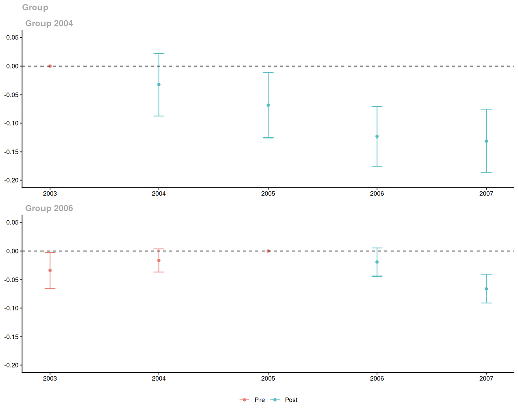

## Event Study

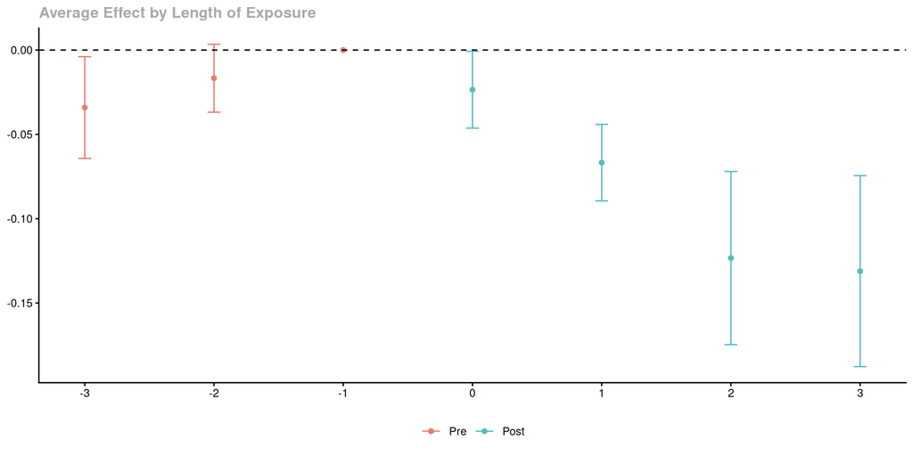

## $\mathbf{\ATT^o}$

|  | (1) |
| --- | --- |
| \(ATT^o\) | -0.057 |
|  | (0.008) |

## Comments

The differences between the CS estimates and the TWFE estimates are fairly large here: the CS estimate is about 50% larger than the TWFE estimate, though results are qualitatively similar.

The differences are fully explained by differences in the weighting schemes. →

## de Chaisemartin and d’Haultfoeuille Weights

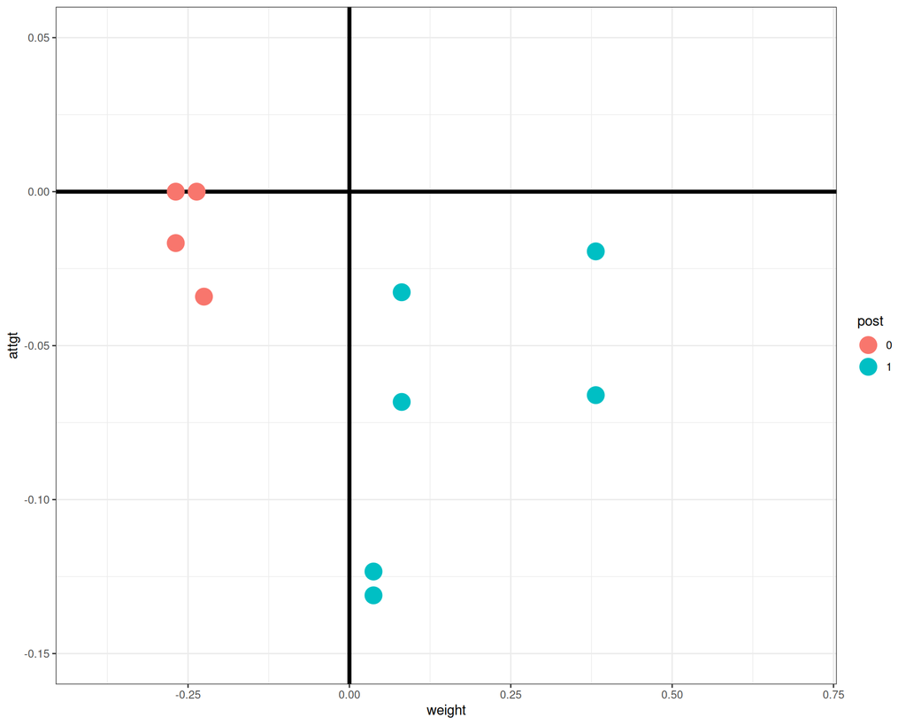

## $\mathbf{\ATT^o}$ Weights

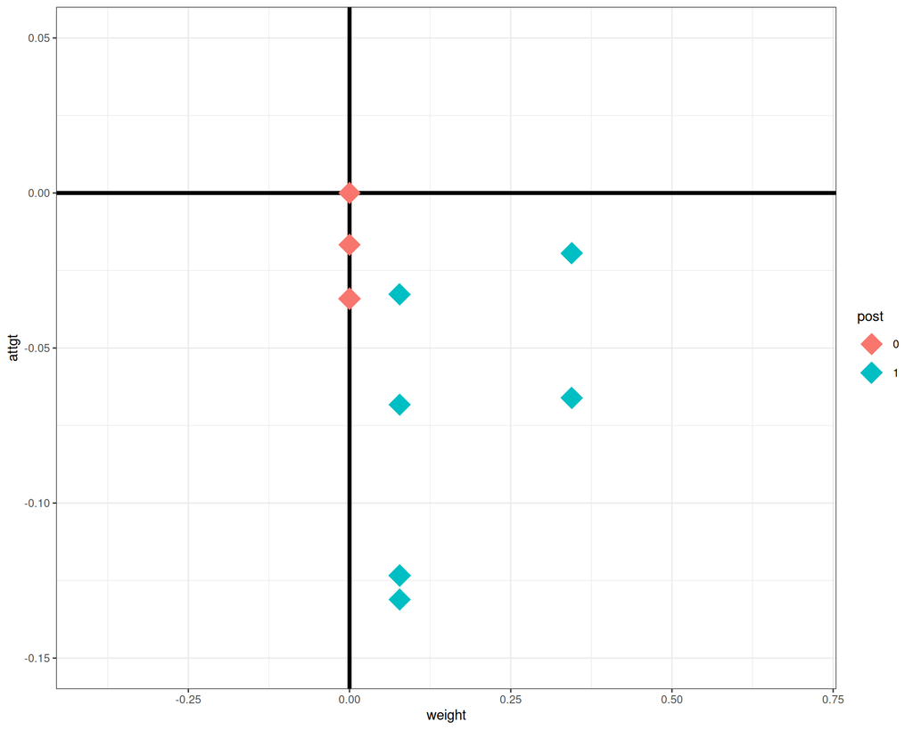

## Weight Comparison

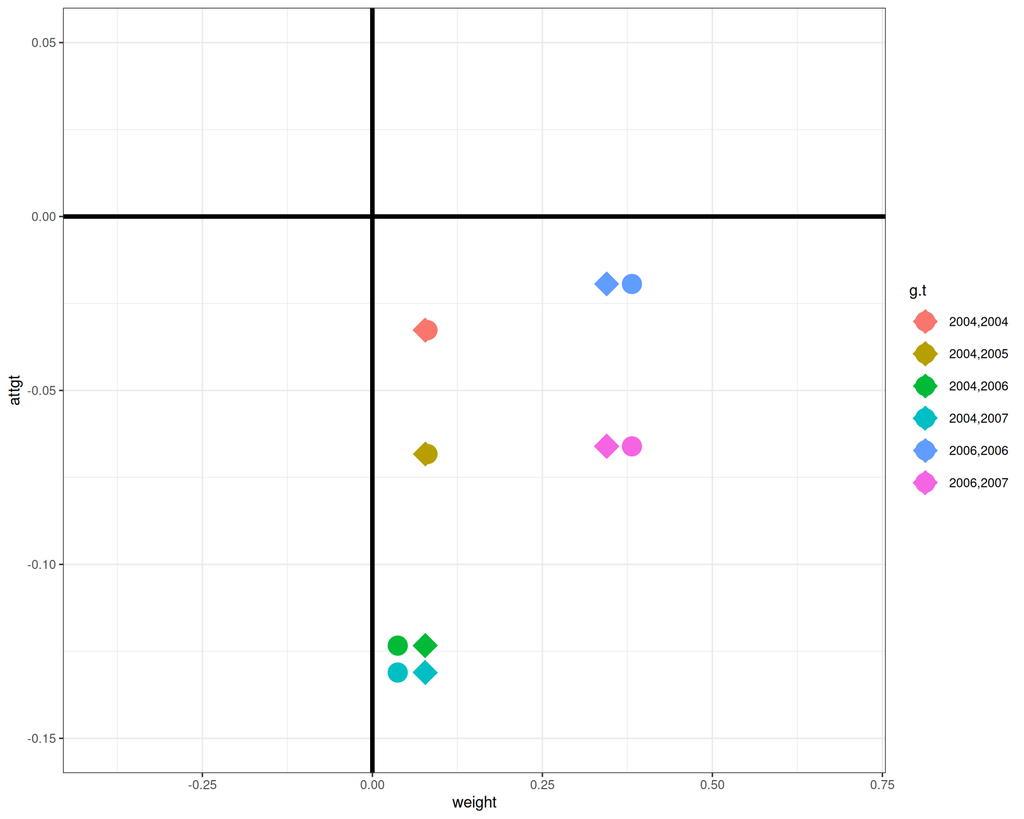

## Discussion

To summarize: $ATT^o = -0.057$ while $\alpha^{TWFE} = -0.038$. This difference can be fully accounted for

- Pre-treatment differences in paths of outcomes across groups: explains about 64% of the difference
- Differences in weights applied to the same post-treatment $ATT(g,t)$: explains about 36% of the difference. [If you apply the post-treatment weights and “zero out” pre-treatment differences, the estimate would be $-0.050$.]

## Discussion

In my experience: this is fairly representative of how much new DiD approaches matter relative to TWFE regressions.

- It does not seem like “catastrophic failure” of TWFE, but (in my view) these are meaningful differences
- The whole discussion hinges crucially on how much treatment effect heterogeneity there is.
  - More TE Het $\implies$ more sensitivity to weighting schemes
  - Just looking at TWFE regression does not give insight into how much TE Het there is

## Additional Comments on Weights

There has been a lot concern about negative weights (both in econometrics and empirical work).

## “Simple” Aggregation

Besides the violations of parallel trends in pre-treatment periods, these weights are further away from $ATT^o$ than the TWFE regression weights are!

Implications:

- Misplaced emphasis on (non-)negative weights
  - If you are “content with” non-negative weights, then you can get any summary measure from $-0.019$ (the smallest $ATT(g,t)$) to $-0.13$ (the largest). This is a wide range of estimates.
- Forward engineering, i.e., clearly stating a target aggregate treatment effect parameter and choosing weights that target that parameter is more important than checking for negative weights

## Conclusion

Not a Panacea:

- Good properties of new approaches are conditional on parallel trends holding

Possible Disadvantages:

- Not yet available for all possible types of treatments where DiD identification strategies are used

Advantages:

- Off-the-shelf robust to treatment effect heterogeneity
- Arguably, simpler and more transparent
- Direct implementation of the DiD identification strategy

# Appendix

## How Do We Choose among Identifying Assumptions?

View #1: Parallel trends as a purely reduced form assumption

- For example, if you have extra pre-treatment periods, you can assess validity in pre-treatment periods

But this is certainly not the only possibility:

- In some disciplines (e.g., biostats) it is relatively more common to assume unconfoundedness conditional on lagged outcomes (i.e., the LO approach above)
- This is also what my undergraduate econometrics students almost always suggest (their judgement is not clouded by having thought about these things too much)
- Or, alternatively, why not take two differences instead of one…

In my view, these seem like fair points

## How Do We Choose among Identifying Assumptions?

View #2: Models that lead to parallel trends assumption. We’ll focus on untreated potential outcomes:
$$Y_{it}(0) = \theta_t + \eta_i + e_{it}$$
Parallel trends is equivalent to this model along with the condition that $\E[e_t | G] = 0$.

Many economic models have this sort of flavor, that the important thing driving differences in outcomes is some latent characteristic (differences in lagged outcomes may proxy this, but not the “deep” explanation)

- See the discussion in Ashenfelter and Card (1985) and Card (2022)

Pros

- No restrictions on treatment effect heterogeneity
- Can allow for some self-selection into treatment

## How Do We Choose among Identifying Assumptions?

View #2: Models that lead to parallel trends assumption. We’ll focus on untreated potential outcomes:
$$Y_{it}(0) = \theta_t + \eta_i + e_{it}$$
Parallel trends is equivalent to this model along with the condition that $\E[e_t | G] = 0$.

Many economic models have this sort of flavor, that the important thing driving differences in outcomes is some latent characteristic (differences in lagged outcomes may proxy this, but not the “deep” explanation)

- See the discussion in Ashenfelter and Card (1985) and Card (2022)

Cons: However, additive separability of $\theta_t$ and $\eta_i$ is crucial for identification

- This is different from other natural experiment methods such as IV and RD, where at least from an identification perspective, there is not model-dependence
- May not be plausible for limited dependent variables
- Also related to results in Roth and Sant’Anna (2023) (about parallel trends and functional form) and Ghanem, Sant’Anna, and Wüthrich (2024) (about selection and parallel trends) [Back]

## How Do These Results Work?

Consider a simplified setting where $\T=2$, but we allow for there to be units that are already treated in the first period.

$\implies$ 3 groups: $G_i=1$, $G_i=2$, $G_i=\infty$

Because there are only two periods, the TWFE regression is equivalent to the regression
$$\begin{align*}
\Delta Y_i = \Delta \theta_{t=2} + \alpha \Delta D_{it=2} + \Delta e_{it=2}
\end{align*}$$

Moreover, $\Delta D_{it=2}$ only takes two values:

- $\Delta D_{it=2} = 0$ for $G_i=1$ and $G_i=\infty$
- $\Delta D_{it=2} = 1$ for $G_i=2$

Thus, this is a fully saturated regression, and we have that
$$\begin{align*}
\alpha = \E[\Delta Y | \Delta D_{t=2} = 1] - \E[\Delta Y | \Delta D_{t=2}=0]
\end{align*}$$

## TWFE Explanation (cont’d)

Starting from the previous slide:
$$\begin{align*}
\alpha = \E[\Delta Y | \Delta D_{t=2} = 1] - \E[\Delta Y | \Delta D_{t=2}=0]
\end{align*}$$
and consider the term on the far right, we have that
$$\begin{align*}
\E[\Delta Y | \Delta D_{t=2}=0] = \E[\Delta Y | G=1] \underbrace{\frac{p_1}{p_1 + p_\infty}}_{=: w_1} + \E[\Delta Y | G=\infty] \underbrace{\frac{p_\infty}{p_1 + p_\infty}}_{=: w_\infty}
\end{align*}$$

where $w_1$ and $w_\infty$ are the relative sizes of group 1 and the never treated group, and notice that $w_1 + w_\infty = 1$. Plugging this back in $\implies$
$$\begin{align*}
\alpha = \Big( \E[\Delta Y | G=2] - \E[\Delta Y | G=1]\Big) w_1 + \Big( \E[\Delta Y | G=2] - \E[\Delta Y|G=\infty]\Big) w_\infty
\end{align*}$$

This is exactly the Goodman-Bacon result! $\alpha$ is a weighted average of all possible 2x2 comparisons

## TWFE Explanation (cont’d)

Let’s keep going:
$$\begin{align*}
\alpha = \underbrace{\Big( \E[\Delta Y | G=2] - \E[\Delta Y | G=1]\Big)}_{\textrm{What is this?}} w_1 + \underbrace{\Big( \E[\Delta Y | G=2] - \E[\Delta Y|G=\infty]\Big)}_{ATT(2,2)} w_\infty
\end{align*}$$
Working on the first term, we have that
$$\begin{aligned}
& \E[\Delta Y_{2} | G=2] - \E[\Delta Y_{2} | G=1] \hspace{300pt}
\end{aligned}$$

## TWFE Explanation (cont’d)

Let’s keep going:
$$\begin{align*}
\alpha = \underbrace{\Big( \E[\Delta Y | G=2] - \E[\Delta Y | G=1]\Big)}_{\textrm{What is this?}} w_1 + \underbrace{\Big( \E[\Delta Y | G=2] - \E[\Delta Y|G=\infty]\Big)}_{ATT(2,2)} w_\infty
\end{align*}$$
Working on the first term, we have that
$$\begin{aligned}
& \E[\Delta Y_{2} | G=2] - \E[\Delta Y_{2} | G=1] \hspace{300pt}\\
&\hspace{10pt} = \E[Y_{2}(2) - Y_{1}(\infty) | G=2] - \E[Y_{2}(1) - Y_{1}(1) | G=1]
\end{aligned}$$

## TWFE Explanation (cont’d)

Let’s keep going:
$$\begin{align*}
\alpha = \underbrace{\Big( \E[\Delta Y | G=2] - \E[\Delta Y | G=1]\Big)}_{\textrm{What is this?}} w_1 + \underbrace{\Big( \E[\Delta Y | G=2] - \E[\Delta Y|G=\infty]\Big)}_{ATT(2,2)} w_\infty
\end{align*}$$
Working on the first term, we have that
$$\begin{aligned}
& \E[\Delta Y_{2} | G=2] - \E[\Delta Y_{2} | G=1] \hspace{300pt}\\
&\hspace{10pt} = \E[Y_{2}(2) - Y_{1}(\infty) | G=2] - \E[Y_{2}(1) - Y_{1}(1) | G=1] \\
&\hspace{10pt} = \E[Y_{2}(2) - Y_{2}(\infty) | G=2] + \underline{\E[Y_{2}(\infty) - Y_{1}(\infty) | G=2]}
\end{aligned}$$

## TWFE Explanation (cont’d)

Let’s keep going:
$$\begin{align*}
\alpha = \underbrace{\Big( \E[\Delta Y | G=2] - \E[\Delta Y | G=1]\Big)}_{\textrm{What is this?}} w_1 + \underbrace{\Big( \E[\Delta Y | G=2] - \E[\Delta Y|G=\infty]\Big)}_{ATT(2,2)} w_\infty
\end{align*}$$
Working on the first term, we have that
$$\begin{aligned}
& \E[\Delta Y_{2} | G=2] - \E[\Delta Y_{2} | G=1] \hspace{300pt}\\
&\hspace{10pt} = \E[Y_{2}(2) - Y_{1}(\infty) | G=2] - \E[Y_{2}(1) - Y_{1}(1) | G=1] \\
&\hspace{10pt} = \E[Y_{2}(2) - Y_{2}(\infty) | G=2] + \underline{\E[Y_{2}(\infty) - Y_{1}(\infty) | G=2]}\\
&\hspace{20pt} - \Big( \E[Y_{2}(1) - Y_{2}(\infty) | G=1] - \E[Y_{1}(1) - Y_{1}(\infty) | G=1] + \underline{\E[Y_{2}(\infty) - Y_{1}(\infty) | G=1]} \Big)
\end{aligned}$$

## TWFE Explanation (cont’d)

Let’s keep going:
$$\begin{align*}
\alpha = \underbrace{\Big( \E[\Delta Y | G=2] - \E[\Delta Y | G=1]\Big)}_{\textrm{What is this?}} w_1 + \underbrace{\Big( \E[\Delta Y | G=2] - \E[\Delta Y|G=\infty]\Big)}_{ATT(2,2)} w_\infty
\end{align*}$$
Working on the first term, we have that
$$\begin{aligned}
& \E[\Delta Y_{2} | G=2] - \E[\Delta Y_{2} | G=1] \hspace{300pt}\\
&\hspace{10pt} = \E[Y_{2}(2) - Y_{1}(\infty) | G=2] - \E[Y_{2}(1) - Y_{1}(1) | G=1] \\
&\hspace{10pt} = \E[Y_{2}(2) - Y_{2}(\infty) | G=2] + \underline{\E[Y_{2}(\infty) - Y_{1}(\infty) | G=2]}\\
&\hspace{20pt} - \Big( \E[Y_{2}(1) - Y_{2}(\infty) | G=1] - \E[Y_{1}(1) - Y_{1}(\infty) | G=1] + \underline{\E[Y_{2}(\infty) - Y_{1}(\infty) | G=1]} \Big)\\
&\hspace{10pt} = \underbrace{ATT(2,2)}_{\textrm{causal effect}} - \underbrace{\Big(ATT(1,2) - ATT(1,1)\Big)}_{\textrm{treatment effect dynamics}}
\end{aligned}$$

Plug this expression back in $\rightarrow$

## TWFE Explanation (cont’d)

Plugging the previous expression back in, we have that
$$\begin{align*}
\alpha = ATT(2,2) + ATT(1,1) w_1 + ATT(1,2)(-w_1)
\end{align*}$$

This is exactly the result in de Chaisemartin and d’Haultfoeuille! $\alpha$ is equal to a weighted average of $ATT(g,t)$’s, but it is possible that some of the weights can be negative.

Also, as they point out, a sufficient condition for the weights to be non-negative is: no treatment effect dynamics $\implies ATT(1,1) = ATT(1,2)$ $\overset{\textrm{here}}{\implies} \alpha = ATT(2,2)$.

- In more complicated settings, this would guarantee no negative weights, but the you would still get a hard-to-understand weighted average of $ATT(g,t)'s$.

[Back]

## Comparing New Approaches to DiD

We’ll discuss:

1. Callaway and Sant’Anna (2021), R: `did`, Stata: `csdid`, Python: `csdid`
2. Sun and Abraham (2021), R: `fixest`, Stata: `eventstudyinteract`
3. Wooldridge (2025), R: `etwfe`, Stata: `JWDiD`
4. Gardner, Thakral, Tô, and Yap (2023) / Borusyak, Jaravel, and Spiess (2024), R: `did2s`, Stata: `did2s` and `did_imputation`

Not including:

1. “Stacked Regression” (Cengiz, Dube, Lindner, and Zipperer (2019), Dube, Girardi, Jordà, and Taylor (2025)), Stata: `stackedev`
2. de Chaisemartin and D’Haultfoeuille (2020), R: `DIDmultiplegt`, Stata: `did_multiplegt`

## Sun and Abraham (2021)

Intuition: Paper points out limitations of event-study versions of the TWFE regressions discussed above:
$$\begin{align*}
Y_{it} = \theta_t + \eta_i + \sum_{e=-(\T-1)}^{-2} \beta_e D_{it}^e + \sum_{e=0}^{\T} \beta_e D_{it}^e + e_{it}
\end{align*}$$
and points out similar issues. In particular, the event study regression is “underspecified” $\implies$ heterogeneous effects can “confound” the treatment effect estimates

Solution: Run fully interacted regression:
$$\begin{align*}
Y_{it} = \theta_t + \eta_i + \sum_{g \in \bar{\mathcal{G}}} \sum_{e \neq -1} \delta^{SA}_{ge} \indicator{G_i=g} \indicator{g+e=t} + e_{it}
\end{align*}$$

2nd step: Aggregate $\delta^{SA}_{ge}$’s across groups (usually into an event study).

- This sidesteps issues with event study regression due treatment effect heterogeneity
- For inference, need to account for two-step estimation procedure

## Wooldridge (2021)

Intuition: Are issues in DiD literature due to limitations of TWFE regressions per se or due to *misspecification* of TWFE regression?

Solution: Proposes running “more interacted” TWFE regression:
$$\begin{align*}
Y_{it} = \theta_t + \eta_i + \sum_{g \in \bar{\mathcal{G}}} \sum_{s=g}^{\T} \alpha_{gt}^W \indicator{G_i=g, t=s} + e_{it}
\end{align*}$$
This is quite similar to Sun and Abraham (2021) except for that it doesn’t include interactions in pre-treatment periods. [The differences about $(g,t)$ relative to $(g,e)$ are trivial.]

- Like SA, this provides robustness to treatment effect heterogeneity by including more interactions
- Like SA, unless mainly interested in $\ATT(g,t)$, have to do second step aggregation that (arguably) ends the “killer feature” of the TWFE regression to begin with

## Gardner et al. (2023) / BJS (2023)

Intuition: Parallel trends is closely connected to a TWFE model *for untreated potential outcomes*
$$Y_{it}(0) = \theta_t + \eta_i + e_{it}$$

Estimation:

- Step 1: Split data into treated and untreated observations
- Step 2: Estimate above model for the set of untreated observations
- Step 3: “Impute” $\hat{Y}_{it}(0) = \hat{\theta}_t + \hat{\eta}_i$ for the treated observations
- $\displaystyle \widehat{\ATT}^{G/BJS}(g,t) = \frac{1}{n_g} \sum_{i=1}^n \indicator{G_i=g}\Big(Y_{it} - \hat{Y}_{it}(0)\Big) \xrightarrow{p} \ATT(g,t)$

Can compute other treatment effect parameters too (e.g., event study or overall average treatment effect)

## Similarities and Differences

In my view, all of the approaches discussed above are fundamentally similar to each other.

In practice, it is sometimes possible to get different results though this is often driven by

- Different estimation strategies trading off efficiency and robustness in different ways
- Different choices in terms of default implementation details in computer code

## Comparison 1: CS and SA

In post-treatment periods, these give numerically identical results: $\widehat{\ATT}^{CS}(g,t) = \hat{\delta}^{SA}_{t,t-g}$

- This is because a fully interacted regression (SA) is equivalent to taking differences in averages across groups (CS)

In pre-treatment periods, code will give different pre-treatment estimates, but this is due to different default choices

- In SA, all results are relative to a fixed base period (typically the period right before treatment)
- In CS, by default, in pre-treatment periods, estimates are of placebo policy effects on impact (i.e., the base period is always the most recent pre-treatment period)

## Comparison 2: SA and Wooldridge

These are clearly closely related, with the difference amounting to whether or not one includes indicators for pre-treatment periods.

It is fair to see this as a way to trade-off robustness and efficiency

- If parallel trends holds across all time periods, then Wooldridge can tend to deliver more efficient estimates (as effectively all pre-treatment periods are used as base periods)
- If parallel trends is violated in some pre-treatment periods but holds post-treatment, Wooldridge estimates will be inconsistent, but SA estimates will be robust to violations of parallel trends in pre-treatment periods.
- See Harmon (2023) for more details

## Comparison 3: Wooldridge and Gardner/BJS

Wooldridge and Gardner/BJS give numerically the same estimates: $\hat{\alpha}^W_{gt} = \widehat{\ATT}^{G/BJS}(g,t)$

Intuition: Including full set of interactions is equivalent to estimating separate models by groups

## Comments

The above discussion emphasizes the conceptual similarities between different proposed alternatives to TWFE regressions in the literature.

The other major source of differences in estimates across procedures is different default options in software implementations. Examples:

1. Different base periods
   - It’s possible to come up with an imputation estimator that uses the base period right before treatment only $\implies$ $\uparrow$ robustness, $\downarrow$ efficiency
   - It’s also possible to do a version of CS with more base periods $\implies$ $\uparrow$ efficiency $\downarrow$ robustness
     - Build-the-trend (i.e., path relative to average pre-treatment outcome) and GMM, Callaway (2023), Marcus and Sant’Anna (2021), Lee and Wooldridge (2023).

## Comments

The above discussion emphasizes the conceptual similarities between different proposed alternatives to TWFE regressions in the literature.

The other major source of differences in estimates across procedures is different default options in software implementations. Examples:

2. Different default target parameters
   - CS emphasizes the “overall” treatment effects discussed above
   - Default implementations of imputation run a regression of $Y_{it}-\hat{Y}_{it}(0)$ on $D_{it}$ which delivers the “simple” overall average treatment effect which just averages all available treatment effects

## Comments

The above discussion emphasizes the conceptual similarities between different proposed alternatives to TWFE regressions in the literature.

The other major source of differences in estimates across procedures is different default options in software implementations. Examples:

3. Different default comparison groups
   - CS and SA by default use the never-treated group as the comparison group
   - Wooldridge and Gardner/BJS by default use all untreated observations as the comparison group
   - But (again) it is straightforward to adapt CS to use the not-yet-treated group as the comparison group, or even a customized comparison group (e.g., not-yet-but-eventually-treated)

## Comments

The above discussion emphasizes the conceptual similarities between different proposed alternatives to TWFE regressions in the literature.

The other major source of differences in estimates across procedures is different default options in software implementations. Examples:

4. Handle covariates in different ways
   - By default, imputation (effectively) uses changes in the covariates over time in estimation
   - CS includes the level of the time-varying covariate in period $g-1$.
   - In Caetano and Callaway (2025), we consider including both changes and levels of covariates

## Comments

See A. C. Baker, Larcker, and Wang (2022) and Callaway (2023) for more substantially more details.

[Back]

# References

Ashenfelter, Orley, and David Card. 1985. “Using the Longitudinal Structure of Earnings to Estimate the Effect of Training Programs.” *The Review of Economics and Statistics* 67 (4): 648–60.

Baker, Andrew C, David F Larcker, and Charles CY Wang. 2022. “How Much Should We Trust Staggered Difference-in-Differences Estimates?” *Journal of Financial Economics* 144 (2): 370–95.

Baker, Andrew, Brantly Callaway, Scott Cunningham, Andrew Goodman-Bacon, and Pedro HC Sant’Anna. 2026. “Difference-in-Differences Designs: A Practitioner’s Guide.” *Journal of Economic Literature* 64 (2): 498–557.

Borusyak, Kirill, Xavier Jaravel, and Jann Spiess. 2024. “Revisiting Event-Study Designs: Robust and Efficient Estimation.” *Review of Economic Studies*, rdae007.

Caetano, Carolina, and Brantly Callaway. 2025. “Difference-in-Differences When Parallel Trends Holds Conditional on Covariates.”

Callaway, Brantly. 2023. “Difference-in-Differences for Policy Evaluation.” In *Handbook of Labor, Human Resources and Population Economics*, edited by Klaus F. Zimmermann, 1–61. Springer International Publishing.

Callaway, Brantly, and Pedro HC Sant’Anna. 2021. “Difference-in-Differences with Multiple Time Periods.” *Journal of Econometrics* 225 (2): 200–230.

Card, David. 2022. “Design-Based Research in Empirical Microeconomics.” *American Economic Review* 112 (6): 1773–81.

Card, David, and Alan Krueger. 1994. “Minimum Wages and Employment: A Case Study of the Fast-Food Industry in New Jersey and Pennsylvania.” *American Economic Review* 84 (4): 772.

Cengiz, Doruk, Arindrajit Dube, Attila Lindner, and Ben Zipperer. 2019. “The Effect of Minimum Wages on Low-Wage Jobs.” *The Quarterly Journal of Economics* 134 (3): 1405–54.

de Chaisemartin, Clement, and Xavier D’Haultfoeuille. 2020. “Two-Way Fixed Effects Estimators with Heterogeneous Treatment Effects.” *American Economic Review* 110 (9): 2964–96.

Dube, Arindrajit, Daniele Girardi, Òscar Jordà, and Alan M Taylor. 2025. “A Local Projections Approach to Difference-in-Differences.” *Journal of Applied Econometrics* 40 (7): 741–58.

Gardner, John, Neil Thakral, Linh T Tô, and Luther Yap. 2023. “Two-Stage Differences in Differences.”

Ghanem, Dalia, Pedro H. C. Sant’Anna, and Kaspar Wüthrich. 2024. “Selection and Parallel Trends.”

Goodman-Bacon, Andrew. 2021. “Difference-in-Differences with Variation in Treatment Timing.” *Journal of Econometrics* 225 (2): 254–77.

Harmon, Nikolaj A. 2023. “Difference-in-Differences and Efficient Estimation of Treatment Effects.”

Lee, Soo Jeong, and Jeffrey M Wooldridge. 2023. “A Simple Transformation Approach to Difference-in-Differences Estimation for Panel Data.”

Marcus, Michelle, and Pedro HC Sant’Anna. 2021. “The Role of Parallel Trends in Event Study Settings: An Application to Environmental Economics.” *Journal of the Association of Environmental and Resource Economists* 8 (2): 235–75.

Roth, Jonathan, and Pedro HC Sant’Anna. 2023. “When Is Parallel Trends Sensitive to Functional Form?” *Econometrica* 91 (2): 737–47.

Sun, Liyang, and Sarah Abraham. 2021. “Estimating Dynamic Treatment Effects in Event Studies with Heterogeneous Treatment Effects.” *Journal of Econometrics* 225 (2): 175–99.

Wooldridge, Jeffrey M. 2025. “Two-Way Fixed Effects, the Two-Way Mundlak Regression, and Difference-in-Differences Estimators.” *Empirical Economics* 69 (5): 2545–87.

## “Simple” Aggregation

Consider the following alternative aggregated treatment effect parameter

Relative to $ATT^o$, early treated units get more weight (because we have more $Y_{it}-\hat{Y}_{it}(0)$ for them).

By construction, weights are all positive. However, they are different from $ATT^o$ weights

## Compute $\mathbf{\ATT^{\text{simple}}}$

```r
att_simple <- did::aggte(attgt, type = "simple")
summary(att_simple)
```

```
Call:
did::aggte(MP = attgt, type = "simple")

Reference: Callaway, Brantly and Pedro H.C. Sant'Anna.  "Difference-in-Differences with Multiple Time Periods." Journal of Econometrics, Vol. 225, No. 2, pp. 200-230, 2021. <https://doi.org/10.1016/j.jeconom.2020.12.001>, <https://arxiv.org/abs/1803.09015>

     ATT    Std. Error     [ 95%  Conf. Int.]
 -0.0646        0.0098    -0.0839     -0.0453 *


---
Signif. codes: `*' confidence band does not cover 0

Control Group:  Never Treated,  Anticipation Periods:  0
Estimation Method:  Doubly Robust
```

## “Simple” Aggregation

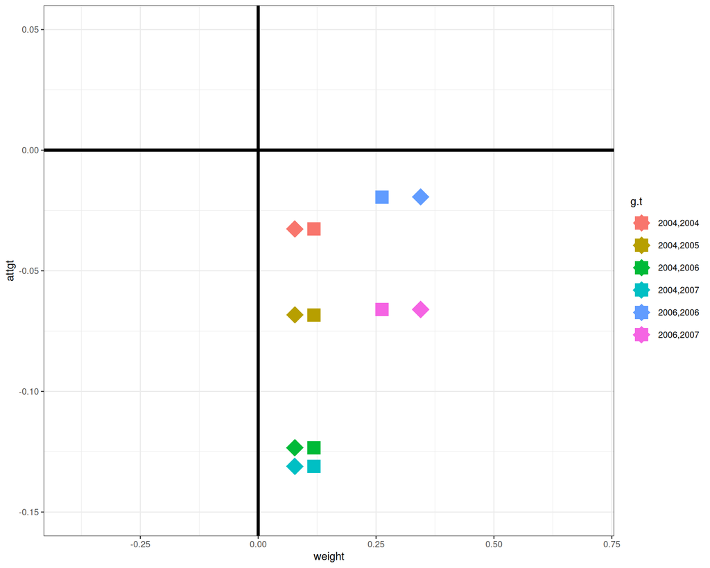

# Appendix

## References

Ashenfelter, Orley, and David Card. 1985. “Using the Longitudinal Structure of Earnings to Estimate the Effect of Training Programs.” *The Review of Economics and Statistics* 67 (4): 648–60.

Baker, Andrew C, David F Larcker, and Charles CY Wang. 2022. “How Much Should We Trust Staggered Difference-in-Differences Estimates?” *Journal of Financial Economics* 144 (2): 370–95.

Baker, Andrew, Brantly Callaway, Scott Cunningham, Andrew Goodman-Bacon, and Pedro HC Sant’Anna. 2026. “Difference-in-Differences Designs: A Practitioner’s Guide.” *Journal of Economic Literature* 64 (2): 498–557.

Borusyak, Kirill, Xavier Jaravel, and Jann Spiess. 2024. “Revisiting Event-Study Designs: Robust and Efficient Estimation.” *Review of Economic Studies*, rdae007.

Caetano, Carolina, and Brantly Callaway. 2025. “Difference-in-Differences When Parallel Trends Holds Conditional on Covariates.”

Callaway, Brantly. 2023. “Difference-in-Differences for Policy Evaluation.” In *Handbook of Labor, Human Resources and Population Economics*, edited by Klaus F. Zimmermann, 1–61. Springer International Publishing.

Callaway, Brantly, and Pedro HC Sant’Anna. 2021. “Difference-in-Differences with Multiple Time Periods.” *Journal of Econometrics* 225 (2): 200–230.

Card, David. 2022. “Design-Based Research in Empirical Microeconomics.” *American Economic Review* 112 (6): 1773–81.

Card, David, and Alan Krueger. 1994. “Minimum Wages and Employment: A Case Study of the Fast-Food Industry in New Jersey and Pennsylvania.” *American Economic Review* 84 (4): 772.

Cengiz, Doruk, Arindrajit Dube, Attila Lindner, and Ben Zipperer. 2019. “The Effect of Minimum Wages on Low-Wage Jobs.” *The Quarterly Journal of Economics* 134 (3): 1405–54.

de Chaisemartin, Clement, and Xavier D’Haultfoeuille. 2020. “Two-Way Fixed Effects Estimators with Heterogeneous Treatment Effects.” *American Economic Review* 110 (9): 2964–96.

Dube, Arindrajit, Daniele Girardi, Òscar Jordà, and Alan M Taylor. 2025. “A Local Projections Approach to Difference-in-Differences.” *Journal of Applied Econometrics* 40 (7): 741–58.

Gardner, John, Neil Thakral, Linh T Tô, and Luther Yap. 2023. “Two-Stage Differences in Differences.”

Ghanem, Dalia, Pedro H. C. Sant’Anna, and Kaspar Wüthrich. 2024. “Selection and Parallel Trends.”

Goodman-Bacon, Andrew. 2021. “Difference-in-Differences with Variation in Treatment Timing.” *Journal of Econometrics* 225 (2): 254–77.

Harmon, Nikolaj A. 2023. “Difference-in-Differences and Efficient Estimation of Treatment Effects.”

Lee, Soo Jeong, and Jeffrey M Wooldridge. 2023. “A Simple Transformation Approach to Difference-in-Differences Estimation for Panel Data.”

Marcus, Michelle, and Pedro HC Sant’Anna. 2021. “The Role of Parallel Trends in Event Study Settings: An Application to Environmental Economics.” *Journal of the Association of Environmental and Resource Economists* 8 (2): 235–75.

Roth, Jonathan, and Pedro HC Sant’Anna. 2023. “When Is Parallel Trends Sensitive to Functional Form?” *Econometrica* 91 (2): 737–47.

Sun, Liyang, and Sarah Abraham. 2021. “Estimating Dynamic Treatment Effects in Event Studies with Heterogeneous Treatment Effects.” *Journal of Econometrics* 225 (2): 175–99.

Wooldridge, Jeffrey M. 2025. “Two-Way Fixed Effects, the Two-Way Mundlak Regression, and Difference-in-Differences Estimators.” *Empirical Economics* 69 (5): 2545–87.